# Trump vs Obama: An analysis of the first year of presidency

## Aim

The purpose of this project is to practice the skills acquired in week 1 of summer boot camp at DigitYser. The skills in question include acquiring datasets from the internet (The files are stored locally, not API requests), extracting relevant data from the datasets, visualizing graphs (using matplotlib, bokeh will be intended for use in a future project) and communicating with others via Jupyter Notebooks.

## Problem

There is no doubt that Trump is quite the controversial president. With his ongoing war against mainstream media, finding articles about him being a bad president can be found almost everwhere. This project however will not focus on the negative, what it will focus on is comparing his performance as a president during the first year of his tenure with that of Obamas's. Please note that since Obama has served two terms, the analysis will be done using data from his first tenure.

## Approach

What makes a successful president ? Success is an arbitrary quality which depends on a number of factors. Taking inspiration from the thesis "What Makes A Successful President? Measuring Presidential Success Through Our Last Five Presidents" by Shirin Sharif which is publicly available from Stanford University website, and also to keep the scale of this project simple, I have decided upon a few key factors that determine a Presidents Success.

The Factors that are of interest are:

1. National Debt (DataSet Downloaded From https://fred.stlouisfed.org/series/GFDEBTN) (Quarterly)
2. Unemployability Rates (DataSet Downloaded From https://fred.stlouisfed.org/series/LRUN64TTUSM156S) (Monthly)
3. Stock Market Index (S&P 500) (DataSet Downloaded From https://www.macrotrends.net/2488/sp500-10-year-daily-chart (Daily)

```
<function matplotlib.pyplot.show(*args, **kw)>
```

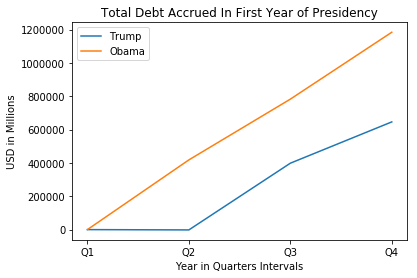

```python
#Importing necessary modules

import pandas as pd
import matplotlib.pyplot as plt

# Initializing variables

obama_debt_inital = 0
obama_debt_final = 0
trump_debt_initial = 0
trump_debt_final = 0
obama_debt_list = []
trump_debt_list = []
filename = 'national debt.csv'

# Defining the extract_debt function. It is made wot be compatible with all the datasets for this project

def extract_data(filename, year, column, skip = None): # The column and skip parameters are present to accomodate the third dataset
    '''Uses filename and year to return a list of records with the desired year'''
    debt_data = pd.read_csv(filename, skiprows = skip )
    required_dates = []
    for x in debt_data[column]:
        if int(x[0:4]) == year:
            required_dates.append(True)
        else:
            required_dates.append(False)
    return list(debt_data.iloc[required_dates, 1])

# Using extract_debt function to get the list of debt during the first year of tenure

obama_debt_list = extract_data(filename, 2009, 'DATE')
trump_debt_list = extract_data(filename, 2017, 'DATE')

# Scaling the debt lists in order to visualize them both as though they started with zero debt
# Inflation is not taken into account between the years as it does not change the overall trend all that much

obama_debt_initial = obama_debt_list[0]
obama_debt_final = obama_debt_list[-1]
trump_debt_initial = trump_debt_list[0]
trump_debt_final = trump_debt_list[-1]

for i in range(len(obama_debt_list)):
    obama_debt_list[i] -= obama_debt_initial
for i in range(len(trump_debt_list)):
    trump_debt_list[i] -= trump_debt_initial

# Plotting Graphs using maptplotlib.pyplot

axis = ['Q1','Q2','Q3','Q4']
plt.plot(axis, trump_debt_list)
plt.plot(axis, obama_debt_list)
plt.legend(['Trump','Obama'])
plt.xlabel('Year in Quarters Intervals')
plt.ylabel('USD in Millions')
plt.title('Total Debt Accrued In First Year of Presidency')
plt.show
```

```
<function matplotlib.pyplot.show(*args, **kw)>
```

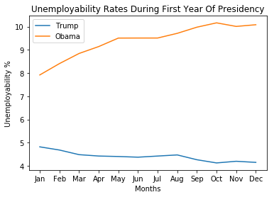

```python
# Using extract_data to get unemployment list as the dataset formats are similiar

filename = 'unemployment rate.csv'
obama_unemploy_list = extract_data(filename, 2009, 'DATE')
trump_unemploy_list = extract_data(filename, 2017, 'DATE')

# Plotting Graphs
axis = ['Jan','Feb','Mar','Apr','May','Jun','Jul','Aug','Sep','Oct','Nov','Dec']
plt.plot(axis,trump_unemploy_list)
plt.plot(axis,obama_unemploy_list)
plt.legend(['Trump','Obama'])
plt.xlabel('Months')
plt.ylabel('Unemployability %')
plt.title('Unemployability Rates During First Year Of Presidency')
plt.show
```

```
<function matplotlib.pyplot.show(*args, **kw)>
```

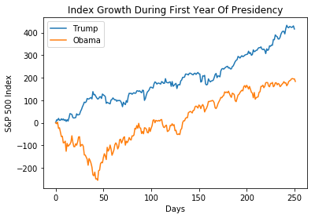

```python
# The paramaters are not the same as the other two as this dataset is from another site and formatted differently
# Modifications to the extract_data function had to be made to accomodate all datasets used

filename = 'stock market.csv'

obama_index = extract_data(filename, 2009, 'date', 12)
trump_index = extract_data(filename, 2017, 'date', 12)

#Scaling DataSets to see rise in index as though they both started at 0

obama_initial = obama_index[0]
obama_final = obama_index[-1]
trump_initial = trump_index[0]
trump_final = trump_index[-1]

for i in range(len(obama_index)):
    obama_index[i] -= obama_initial
for i in range(len(trump_index)):
    trump_index[i] -= trump_initial

# Plotting Graphs

plt.plot(trump_index)
plt.plot(obama_index)
plt.legend(['Trump','Obama'])
plt.xlabel('Days')
plt.ylabel('S&P 500 Index')
plt.title('Index Growth During First Year Of Presidency')
plt.show
```

## Observation

In the first graph, we notice a continuous upward trend in expenditure by president Obama since the day he took office. Obama placed international relations as a top priority and went on many trips to meet world leaders (Which is a very expensive operation). Add the fact that he inherited two wars, it is safe to say that he did little to reduce the debt and increased it further. Trump's trend is interesting to note as in the first quarter, the debt had started to recover, albeit slightly but contines in an upward trend afterwards, though not at the same scale as Obama in the first year.

In the second graph, Obama had inherited a rather high unemployability rate to begin with but it continues upwards during the first year. It is safe to assume that reducing unemployability was not the focus of his presidency during the first year. It was only during his second tenure that he made active policies to reduce unemployability as it posed long term economic impact. Trump, thanks to policies placed by Obama during the second tenure, enjoys a rather low unemployability rate which continued in a downward trend during his first year. While people might argue that this is all thanks to Obama, and to some degree it is true. It is interesting to note that Obama's policies focused on helping the minorites find jobs, primarily the African-American population throught better education and is probably his most successful accomplishment to this day. Trump's goals were more geared towards creating jobs. While both were successful in ths category, the first year of presidency, sees Obama struggling with it while Trump was quite comfortable.

While the previous two graphs did show differences in their performance, the stock market index is the one that truly sets them apart. Trump, hailing from a business background, had the support of many corporations. Part of his campaign was to make promises for businesses to flourish. His tax cut plan benefits businesses who operate on large scale the most. Impact on local businesses and individuals however is up for debate and not a focus for this project. Trump enjoys a very positive upward trend throughout his first year. Obama's first year, much like the first quarter as seen in the first graph, did not go well. This was again due to him inheriting two wars which was bleeding the economy at the time which left many wondering if ivesting at the time was the right option. He did well later during the year but still not at the same scale that Trump has done. This could be due to the 8 year time difference and a variety of other factors but as far stock market index goes, Trump is considered a major success.

## Conclusion

Despite hating Trump being the trendy thing in the United States and the world over, a lot of people tend to forget his personality has little to do with his success as a president. Success as mentioned before is subjective, and for the sake of this project, success will be measured upon the three factors used. I am aware that this is a more complicated issue than just comparing a few statistics, but I believe that this is a good place to start. From what was observed, it is safe to assume that Obama during his first year of presidency was struggling due to him inheriting a mess. It was not until much later on in his presdiency that he achieved notable success in certain sectors. While people may argue that Trump is seeing good trends and is seeing success thanks to what Obama had left him, it should be noted that Trump had been sweared in as President with the strongest backlash the world has ever seen. He is attacked everyday by mainstream media, has many notable critics finding faults with everything he does, had multiple bills denied by congress, was forced to tackle them with the most number of executive orders any president had ever done before in his first year alone. But despite the odds, Trump has achieved good trends during his first year.

## Note

There is no political agenda for this mini project. I am not a fan of Trump, nor am I a hater. I am just trying to see him in a different perspective that people choose to ignore due to all the hate going around him. This was done to compare one of the most hated presidents when he was sworn in to one the most beloved presidents when he was sworn in.